# MACHINE LEARNING - HYPERPARAMETER TUNING

## Ricardo López Ruiz

Date: 17/05/2021

## Abstract:

Different machine learning techniques are used to improve the model performance applied to analyze and identify the customers who will leave their credit card services in a bank.

## Models and Tuning used in this project:

'Logistic Regression', 'Bagging and Boosting Classifiers', 'Hyperparameter tuning using grid and random searches', 'Model performances'

# Project - CreditCard Users Churn Prediction

## **Context:**

You as a Data scientist at Thera bank need to come up with a classification model that will help bank improve their services so that customers do not renounce their credit cards.

## **Background:**

The Thera bank recently saw a steep decline in the number of users of their credit card, credit cards are a good source of income for banks because of different kinds of fees charged by the banks like annual fees, balance transfer fees, and cash advance fees, late payment fees, foreign transaction fees, and others. Some fees are charged on every user irrespective of usage, while others are charged under specified circumstances.

Customers’ leaving credit cards services would lead bank to loss, so the bank wants to analyze the data of customers’ and identify the customers who will leave their credit card services and reason for same – so that bank could improve upon those areas.

## **Objective:**

- Explore and visualize the dataset.
- Build a classification model to predict if the customer is going to churn or not
- Optimize the model using appropriate techniques
- Generate a set of insights and recommendations that will help the bank

## **Data Description:**

### Data Dictionary

Customer details:

- CLIENTNUM: Client number. Unique identifier for the customer holding the account
- Attrition_Flag: Internal event (customer activity) variable - if the account is closed then 1 else 0
- Customer_Age: Age in Years
- Gender: Gender of the account holder
- Dependent_count: Number of dependents
- Education_Level: Educational Qualification of the account holder
- Marital_Status: Marital Status of the account holder
- Income_Category: Annual Income Category of the account holder
- Card_Category: Type of Card
- Months_on_book: Period of relationship with the bank
- Total_Relationship_Count: Total no. of products held by the customer
- Months_Inactive_12_mon: No. of months inactive in the last 12 months
- Contacts_Count_12_mon: No. of Contacts in the last 12 months
- Credit_Limit: Credit Limit on the Credit Card
- Total_Revolving_Bal: Total Revolving Balance on the Credit Card
- Avg_Open_To_Buy: Open to Buy Credit Line (Average of last 12 months)
- Total_Amt_Chng_Q4_Q1: Change in Transaction Amount (Q4 over Q1)
- Total_Trans_Amt: Total Transaction Amount (Last 12 months)
- Total_Trans_Ct: Total Transaction Count (Last 12 months)
- Total_Ct_Chng_Q4_Q1: Change in Transaction Count (Q4 over Q1)
- Avg_Utilization_Ratio: Average Card Utilization Ratio

## Index

- Overview of the dataset
- EDA
- Data Pre-processing
- Model building - Logistic Regression
- Model building - Bagging and Boosting
- Hyperparameter tuning using grid search
- Hyperparameter tuning using random search
- Model Performances
- Actionable Insights \& Recommendations

## Overview of the dataset

**Let's start by importing libraries we need.**

```python
import warnings
warnings.filterwarnings("ignore")

import numpy as np
import pandas as pd
import seaborn as sns
import matplotlib.pyplot as plt
%matplotlib inline
```

```python
#Loading dataset
data=pd.read_csv("BankChurners.csv")
```

**View the first rows of the dataset.**

```python
data.head()
```

|  | CLIENTNUM | Attrition_Flag | Customer_Age | Gender | Dependent_count | Education_Level | Marital_Status | Income_Category | Card_Category | Months_on_book | ... | Months_Inactive_12_mon | Contacts_Count_12_mon | Credit_Limit | Total_Revolving_Bal | Avg_Open_To_Buy | Total_Amt_Chng_Q4_Q1 | Total_Trans_Amt | Total_Trans_Ct | Total_Ct_Chng_Q4_Q1 | Avg_Utilization_Ratio |
| --- | --- | --- | --- | --- | --- | --- | --- | --- | --- | --- | --- | --- | --- | --- | --- | --- | --- | --- | --- | --- | --- |
| 0 | 768805383 | Existing Customer | 45 | M | 3 | High School | Married | $60K - $80K | Blue | 39 | ... | 1 | 3 | 12691.0 | 777 | 11914.0 | 1.335 | 1144 | 42 | 1.625 | 0.061 |
| 1 | 818770008 | Existing Customer | 49 | F | 5 | Graduate | Single | Less than $40K | Blue | 44 | ... | 1 | 2 | 8256.0 | 864 | 7392.0 | 1.541 | 1291 | 33 | 3.714 | 0.105 |
| 2 | 713982108 | Existing Customer | 51 | M | 3 | Graduate | Married | $80K - $120K | Blue | 36 | ... | 1 | 0 | 3418.0 | 0 | 3418.0 | 2.594 | 1887 | 20 | 2.333 | 0.000 |
| 3 | 769911858 | Existing Customer | 40 | F | 4 | High School | Unknown | Less than $40K | Blue | 34 | ... | 4 | 1 | 3313.0 | 2517 | 796.0 | 1.405 | 1171 | 20 | 2.333 | 0.760 |
| 4 | 709106358 | Existing Customer | 40 | M | 3 | Uneducated | Married | $60K - $80K | Blue | 21 | ... | 1 | 0 | 4716.0 | 0 | 4716.0 | 2.175 | 816 | 28 | 2.500 | 0.000 |

5 rows × 21 columns

**Check data types and number of non-null values for each column.**

```python
data.info()
```

```
<class 'pandas.core.frame.DataFrame'>
RangeIndex: 10127 entries, 0 to 10126
Data columns (total 21 columns):
 #   Column                    Non-Null Count  Dtype
---  ------                    --------------  -----
 0   CLIENTNUM                 10127 non-null  int64
 1   Attrition_Flag            10127 non-null  object
 2   Customer_Age              10127 non-null  int64
 3   Gender                    10127 non-null  object
 4   Dependent_count           10127 non-null  int64
 5   Education_Level           10127 non-null  object
 6   Marital_Status            10127 non-null  object
 7   Income_Category           10127 non-null  object
 8   Card_Category             10127 non-null  object
 9   Months_on_book            10127 non-null  int64
 10  Total_Relationship_Count  10127 non-null  int64
 11  Months_Inactive_12_mon    10127 non-null  int64
 12  Contacts_Count_12_mon     10127 non-null  int64
 13  Credit_Limit              10127 non-null  float64
 14  Total_Revolving_Bal       10127 non-null  int64
 15  Avg_Open_To_Buy           10127 non-null  float64
 16  Total_Amt_Chng_Q4_Q1      10127 non-null  float64
 17  Total_Trans_Amt           10127 non-null  int64
 18  Total_Trans_Ct            10127 non-null  int64
 19  Total_Ct_Chng_Q4_Q1       10127 non-null  float64
 20  Avg_Utilization_Ratio     10127 non-null  float64
dtypes: float64(5), int64(10), object(6)
memory usage: 1.6+ MB
```

- We can see that there are total 21 columns and 10127 number of rows in the dataset.
- All columns' data type is either integer or float or object.
- The non-null values of each column is equal to the number of total rows in the dataset i.e. there are not null values.

```python
#Total of null data by rows
data.isna().sum()
```

```
CLIENTNUM                   0
Attrition_Flag              0
Customer_Age                0
Gender                      0
Dependent_count             0
Education_Level             0
Marital_Status              0
Income_Category             0
Card_Category               0
Months_on_book              0
Total_Relationship_Count    0
Months_Inactive_12_mon      0
Contacts_Count_12_mon       0
Credit_Limit                0
Total_Revolving_Bal         0
Avg_Open_To_Buy             0
Total_Amt_Chng_Q4_Q1        0
Total_Trans_Amt             0
Total_Trans_Ct              0
Total_Ct_Chng_Q4_Q1         0
Avg_Utilization_Ratio       0
dtype: int64
```

```python
#Total of number of rows with some null data
data.isnull().any(axis=1).sum()
```

```
0
```

**Checking the percentage of customers with Avg_Utilization_Ratio=0 & Avg_Utilization_Ratio<0.333**

```python
#Percentage of customers with low use of the cards
print(len(data))
print(data[data["Avg_Utilization_Ratio"]==0].shape)
print(data[data["Avg_Utilization_Ratio"]<0.333].shape)
print(data["Avg_Utilization_Ratio"].value_counts(bins=3))
print('% Costumers Not Using Credit = ',100*data["Avg_Utilization_Ratio"].value_counts()[0]/len(data),'%')
print('% Costumers Using Credit < 0.333 = ',100*data[data["Avg_Utilization_Ratio"]<0.333].shape[0]/len(data),'%')
```

```
10127
(2470, 21)
(6491, 21)
(-0.001999, 0.333]    6491
(0.333, 0.666]        2333
(0.666, 0.999]        1303
Name: Avg_Utilization_Ratio, dtype: int64
% Costumers Not Using Credit =  24.390243902439025 %
% Costumers Using Credit < 0.333 =  64.09598104078206 %
```

**Checking the percentage of customers with Attrition_Flag=0 & Attrition_Flag=1**

```python
#Percentage of attrited customers
print(len(data))
print(data[data["Attrition_Flag"]=="Attrited Customer"].shape)
print(data["Attrition_Flag"].value_counts())
print('% Attrited Costumers = ',100*data["Attrition_Flag"].value_counts()[1]/len(data),'%')
```

```
10127
(1627, 21)
Existing Customer    8500
Attrited Customer    1627
Name: Attrition_Flag, dtype: int64
% Attrited Costumers =  16.065962279055988 %
```

## First steps to treat the data

- The percentage not using credit is 24%, with very low use of credit 64% but the attrited costumers is the 16%.
- We can drop 'CLIENTNUM' column as it is an ID variable and will not add value to the model.
- There are no missing values in the data to be treated.
- Lets convert the columns with an 'object' datatype into categorical variables.
- It is easily verified that Avg_Open_To_Buy = Credit_Limit - Total_Revolving_Bal, then they are completely correlated variables and we can drop one of them, for instance 'Avg_Open_To_Buy'.
- Also it can be easily verified that Avg_Utilization_Ratio = Total_Revolving_Bal / Credit_Limit, then they are completely correlated variables and we will drop later one of them too.

```python
#Dropping columns from the dataframe "data" in a new dataframe "data1"
data1 = data.drop(columns=['CLIENTNUM','Avg_Open_To_Buy']).copy()
data1.shape
```

```
(10127, 19)
```

```python
# Reconverting the 'object' data in 'categorical' data
for feature in data1.columns: # Loop through all columns in the dataframe
    if data1[feature].dtype == 'object': # Only apply for columns with objects
        data1[feature] = pd.Categorical(data1[feature])# Replace objects with category
data1.info()
```

```
<class 'pandas.core.frame.DataFrame'>
RangeIndex: 10127 entries, 0 to 10126
Data columns (total 19 columns):
 #   Column                    Non-Null Count  Dtype
---  ------                    --------------  -----
 0   Attrition_Flag            10127 non-null  category
 1   Customer_Age              10127 non-null  int64
 2   Gender                    10127 non-null  category
 3   Dependent_count           10127 non-null  int64
 4   Education_Level           10127 non-null  category
 5   Marital_Status            10127 non-null  category
 6   Income_Category           10127 non-null  category
 7   Card_Category             10127 non-null  category
 8   Months_on_book            10127 non-null  int64
 9   Total_Relationship_Count  10127 non-null  int64
 10  Months_Inactive_12_mon    10127 non-null  int64
 11  Contacts_Count_12_mon     10127 non-null  int64
 12  Credit_Limit              10127 non-null  float64
 13  Total_Revolving_Bal       10127 non-null  int64
 14  Total_Amt_Chng_Q4_Q1      10127 non-null  float64
 15  Total_Trans_Amt           10127 non-null  int64
 16  Total_Trans_Ct            10127 non-null  int64
 17  Total_Ct_Chng_Q4_Q1       10127 non-null  float64
 18  Avg_Utilization_Ratio     10127 non-null  float64
dtypes: category(6), float64(4), int64(9)
memory usage: 1.1 MB
```

```python
# Checking the chages in the data are ok
data1.head()
```

|  | Attrition_Flag | Customer_Age | Gender | Dependent_count | Education_Level | Marital_Status | Income_Category | Card_Category | Months_on_book | Total_Relationship_Count | Months_Inactive_12_mon | Contacts_Count_12_mon | Credit_Limit | Total_Revolving_Bal | Total_Amt_Chng_Q4_Q1 | Total_Trans_Amt | Total_Trans_Ct | Total_Ct_Chng_Q4_Q1 | Avg_Utilization_Ratio |
| --- | --- | --- | --- | --- | --- | --- | --- | --- | --- | --- | --- | --- | --- | --- | --- | --- | --- | --- | --- |
| 0 | Existing Customer | 45 | M | 3 | High School | Married | $60K - $80K | Blue | 39 | 5 | 1 | 3 | 12691.0 | 777 | 1.335 | 1144 | 42 | 1.625 | 0.061 |
| 1 | Existing Customer | 49 | F | 5 | Graduate | Single | Less than $40K | Blue | 44 | 6 | 1 | 2 | 8256.0 | 864 | 1.541 | 1291 | 33 | 3.714 | 0.105 |
| 2 | Existing Customer | 51 | M | 3 | Graduate | Married | $80K - $120K | Blue | 36 | 4 | 1 | 0 | 3418.0 | 0 | 2.594 | 1887 | 20 | 2.333 | 0.000 |
| 3 | Existing Customer | 40 | F | 4 | High School | Unknown | Less than $40K | Blue | 34 | 3 | 4 | 1 | 3313.0 | 2517 | 1.405 | 1171 | 20 | 2.333 | 0.760 |
| 4 | Existing Customer | 40 | M | 3 | Uneducated | Married | $60K - $80K | Blue | 21 | 5 | 1 | 0 | 4716.0 | 0 | 2.175 | 816 | 28 | 2.500 | 0.000 |

## EDA

### Perform an Exploratory Data Analysis on the data

- Univariate analysis - Bivariate analysis - Use of appropriate visualizations to identify the patterns and insights - Any other exploratory deep dive

### Illustrate the insights based on EDA

- Key meaningful observations on the relationship between variables

**Summary of the dataset**

```python
# Summary of columns with low integer data
data1[['Customer_Age','Months_on_book','Total_Relationship_Count','Total_Trans_Ct']].describe().T
```

|  | count | mean | std | min | 25% | 50% | 75% | max |
| --- | --- | --- | --- | --- | --- | --- | --- | --- |
| Customer_Age | 10127.0 | 46.325960 | 8.016814 | 26.0 | 41.0 | 46.0 | 52.0 | 73.0 |
| Months_on_book | 10127.0 | 35.928409 | 7.986416 | 13.0 | 31.0 | 36.0 | 40.0 | 56.0 |
| Total_Relationship_Count | 10127.0 | 3.812580 | 1.554408 | 1.0 | 3.0 | 4.0 | 5.0 | 6.0 |
| Total_Trans_Ct | 10127.0 | 64.858695 | 23.472570 | 10.0 | 45.0 | 67.0 | 81.0 | 139.0 |

- Mean and median value of 'Costumer_Age' is approx 46.
- Mean and median value for 'Months_on_book' is approx 36.
- Mean and median value for 'Total_Relationship_Count' is approx 4.
- Mean and median value for 'Total_Trans_Ct' is approx 65 and 67, respectively.
- These variables seem to have not much skewed distributions, as mean and median are very similar for all them.
- Also the excessive max value in 'Total_Trans_Ct' warn us about the existence of outliers.

```python
# Summary of columns with high integer data and real data
data1[['Credit_Limit','Total_Revolving_Bal','Total_Amt_Chng_Q4_Q1','Total_Ct_Chng_Q4_Q1','Avg_Utilization_Ratio']].describe().T
```

|  | count | mean | std | min | 25% | 50% | 75% | max |
| --- | --- | --- | --- | --- | --- | --- | --- | --- |
| Credit_Limit | 10127.0 | 8631.953698 | 9088.776650 | 1438.3 | 2555.000 | 4549.000 | 11067.500 | 34516.000 |
| Total_Revolving_Bal | 10127.0 | 1162.814061 | 814.987335 | 0.0 | 359.000 | 1276.000 | 1784.000 | 2517.000 |
| Total_Amt_Chng_Q4_Q1 | 10127.0 | 0.759941 | 0.219207 | 0.0 | 0.631 | 0.736 | 0.859 | 3.397 |
| Total_Ct_Chng_Q4_Q1 | 10127.0 | 0.712222 | 0.238086 | 0.0 | 0.582 | 0.702 | 0.818 | 3.714 |
| Avg_Utilization_Ratio | 10127.0 | 0.274894 | 0.275691 | 0.0 | 0.023 | 0.176 | 0.503 | 0.999 |

**Number of unique values in each column**

```python
data1.nunique()
```

```
Attrition_Flag                 2
Customer_Age                  45
Gender                         2
Dependent_count                6
Education_Level                7
Marital_Status                 4
Income_Category                6
Card_Category                  4
Months_on_book                44
Total_Relationship_Count       6
Months_Inactive_12_mon         7
Contacts_Count_12_mon          7
Credit_Limit                6205
Total_Revolving_Bal         1974
Total_Amt_Chng_Q4_Q1        1158
Total_Trans_Amt             5033
Total_Trans_Ct               126
Total_Ct_Chng_Q4_Q1          830
Avg_Utilization_Ratio        964
dtype: int64
```

**Correction/Grouping of data values**

```python
#we check number of grades in the different columns presenting with a few values
print(data1['Attrition_Flag'].value_counts())
print(data1['Gender'].value_counts())
print(data1['Dependent_count'].value_counts())
print(data1['Education_Level'].value_counts())
print(data1['Marital_Status'].value_counts())
print(data1['Income_Category'].value_counts())
print(data1['Card_Category'].value_counts())
print(data1['Total_Relationship_Count'].value_counts())
print(data1['Months_Inactive_12_mon'].value_counts())
print(data1['Contacts_Count_12_mon'].value_counts())
```

```
Existing Customer    8500
Attrited Customer    1627
Name: Attrition_Flag, dtype: int64
F    5358
M    4769
Name: Gender, dtype: int64
3    2732
2    2655
1    1838
4    1574
0     904
5     424
Name: Dependent_count, dtype: int64
Graduate         3128
High School      2013
Unknown          1519
Uneducated       1487
College          1013
Post-Graduate     516
Doctorate         451
Name: Education_Level, dtype: int64
Married     4687
Single      3943
Unknown      749
Divorced     748
Name: Marital_Status, dtype: int64
Less than $40K    3561
$40K - $60K       1790
$80K - $120K      1535
$60K - $80K       1402
Unknown           1112
$120K +            727
Name: Income_Category, dtype: int64
Blue        9436
Silver       555
Gold         116
Platinum      20
Name: Card_Category, dtype: int64
3    2305
4    1912
5    1891
6    1866
2    1243
1     910
Name: Total_Relationship_Count, dtype: int64
3    3846
2    3282
1    2233
4     435
5     178
6     124
0      29
Name: Months_Inactive_12_mon, dtype: int64
3    3380
2    3227
1    1499
4    1392
0     399
5     176
6      54
Name: Contacts_Count_12_mon, dtype: int64
```

- There are unknown categories in several features: 'Education_Level', 'Marital_Status', 'Income_Category'.
- In the 'Education_Level' in order to simplify this classification we can assimilate the categories 'College' and 'Graduate', and also 'Doctorate' and 'Post-Graduate'.
- As the number of 'Unknown' categories is high and similar to the other ones we can consider this type as a valid category.

```python
# Replacing College with Graduate
data1["Education_Level"] = data1["Education_Level"].replace("College", "Graduate")
# Replacing Doctorate with Post-Graduate
data1["Education_Level"] = data1["Education_Level"].replace("Doctorate", "Post-Graduate")
#Verifying result
print(data1['Education_Level'].value_counts())
```

```
Graduate         4141
High School      2013
Unknown          1519
Uneducated       1487
Post-Graduate     967
Name: Education_Level, dtype: int64
```

### Univariate analysis

```python
# While doing uni-variate analysis of numerical variables we want to study their central tendency
# and dispersion.
# Let us write a function that will help us create boxplot and histogram for any input numerical
# variable.
# This function takes the numerical column as the input and returns the boxplots
# and histograms for the variable.

def histogram_boxplot(feature, figsize=(15,10), bins = None):
    """ Boxplot and histogram combined
    feature: 1-d feature array
    figsize: size of fig (default (9,8))
    bins: number of bins (default None / auto)
    """
    f2, (ax_box2, ax_hist2) = plt.subplots(nrows = 2, # Number of rows of the subplot grid= 2
                                           sharex = True, # x-axis will be shared among all subplots
                                           gridspec_kw = {"height_ratios": (.25, .75)},
                                           figsize = figsize
                                           ) # creating the 2 subplots
    sns.boxplot(feature, ax=ax_box2, showmeans=True, color='violet') # boxplot will be created and a star will indicate the mean value of the column
    sns.distplot(feature, kde=F, ax=ax_hist2, bins=bins,palette="winter") if bins else sns.distplot(feature, kde=False, ax=ax_hist2) # For histogram
    mean=feature.mean()
    median=feature.median()
    ax_hist2.axvline(median, color='black', linestyle='-') # Add median to the histogram
    ax_hist2.axvline(mean, color='green', linestyle='--') # Add mean to the histogram
```

**Observations on Customer_Age**

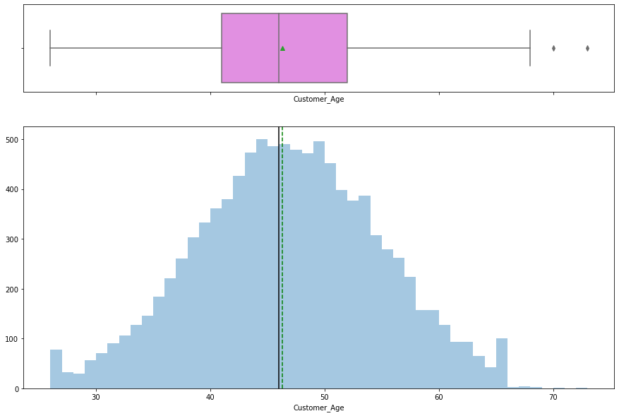

```python
histogram_boxplot(data1['Customer_Age'])
```

- Age has an approx symmetric distribution with mean and median near to 46
- As evident from the boxplot, there are some few outliers in a reasonable range for this variable

**Observations on 'Months_on_book'**

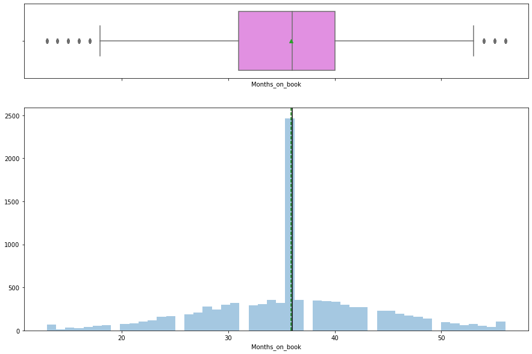

```python
histogram_boxplot(data1['Months_on_book'])
```

- The distribution is symmetrically distributed with the mean and median are approx. equal to 36
- There are some few outliers in the distribution of this variable

**Observations on 'Credit_Limit'**

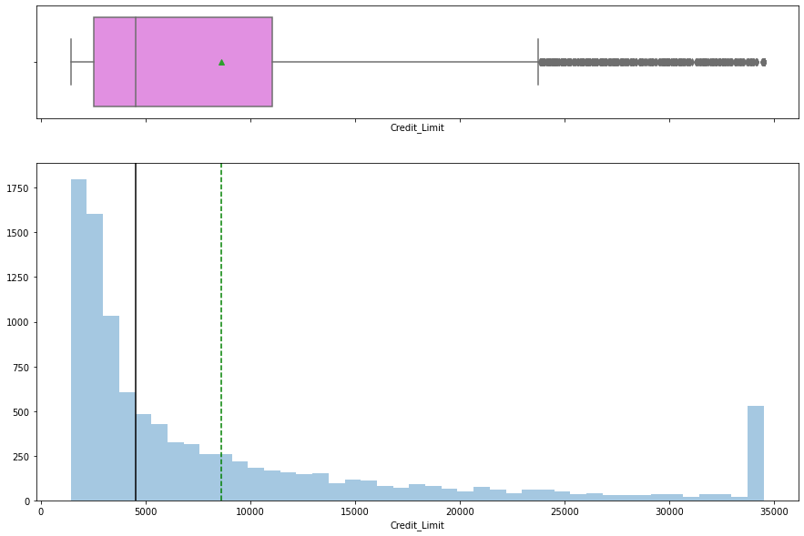

```python
histogram_boxplot(data1['Credit_Limit'])
```

- The distribution is a very skewed distribution with a high peak to the right. This is not important because it represents a limit in the credit card that very occasionally is used.
- There are so many outliers that it doesnt have a sense to do a capping because we only would displace the high peak of the right to another smaller position.
- Moreover this variable possibly will be dropped in a later analysis due to its strong correlation with other variables.

**Observations on 'Total_Revolving_Bal'**

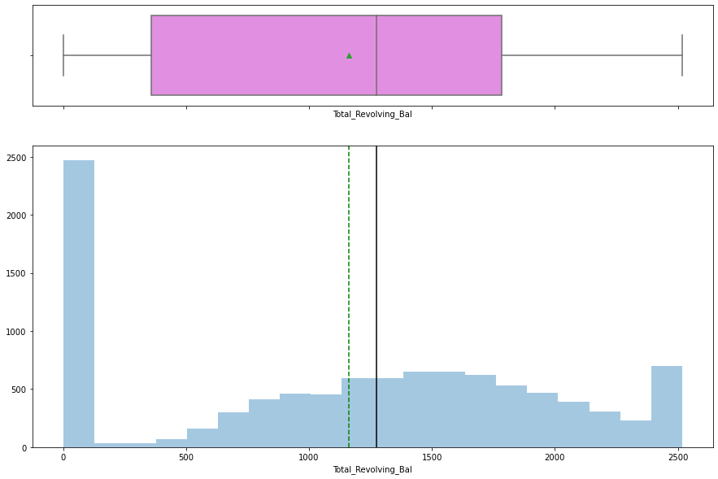

```python
histogram_boxplot(data1['Total_Revolving_Bal'])
```

```python
#Top highest/smallest values in Total_Revolving_Bal
print(data1['Total_Revolving_Bal'].nlargest(1))
print(data1['Total_Revolving_Bal'].nsmallest(1))
```

```
3    2517
Name: Total_Revolving_Bal, dtype: int64
2    0
Name: Total_Revolving_Bal, dtype: int64
```

- Total_Revolving_Bal has a left skewed distribution due to the great number of customers having a near zero revolving balance.
- Distribution is not symmetric but mean and median are approx equal with values 1160 and 1270, respectively.
- There are not outliers in this variable.

**Observations on 'Total_Amt_Chng_Q4_Q1'**

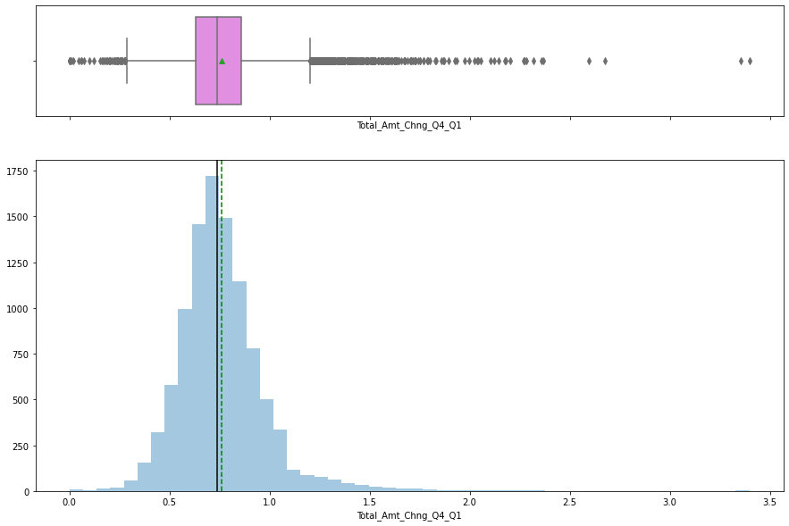

```python
histogram_boxplot(data1['Total_Amt_Chng_Q4_Q1'])
```

- Total_Amt_Chng_Q4_Q1 has a near symmetric distribution around the value 0.75.
- Most of the customers spend more money in the first quarter Q1 than in the fourth quarter Q4.
- There are many outliers to both sides. In the right side we can perform a capping at the value 2.0

```python
# Capping values for number of Total_Amt_Chng_Q4_Q1 at 2.0
data1["Total_Amt_Chng_Q4_Q1"].clip(upper=2.0, inplace=True)
```

**Observations on 'Total_Ct_Chng_Q4_Q1'**

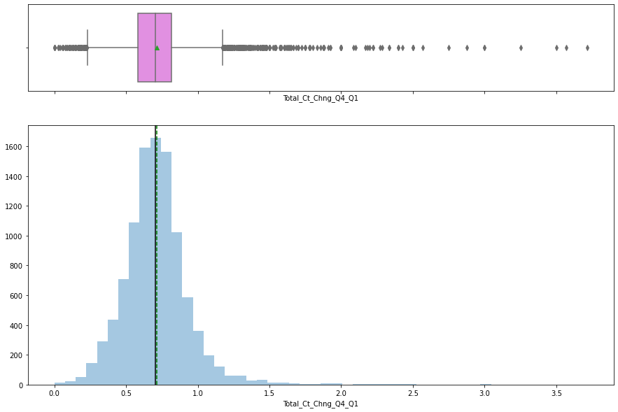

```python
histogram_boxplot(data1['Total_Ct_Chng_Q4_Q1'])
```

- Total_Ct_Chng_Q4_Q1 has a similar behavior to the previous variable Total_Amt_Chng_Q4_Q1.
- Most of the customers spend more money in the first quarter Q1 than in the fourth quarter Q4.
- There are many outliers to both sides. In the right side we can perform a capping at the value 2.0

```python
# Capping values for number of Total_Ct_Chng_Q4_Q1 at 2.0
data1["Total_Ct_Chng_Q4_Q1"].clip(upper=2.0, inplace=True)
```

**Observations on 'Total_Trans_Amt'**

```
4404.086303939963
3899.0
```

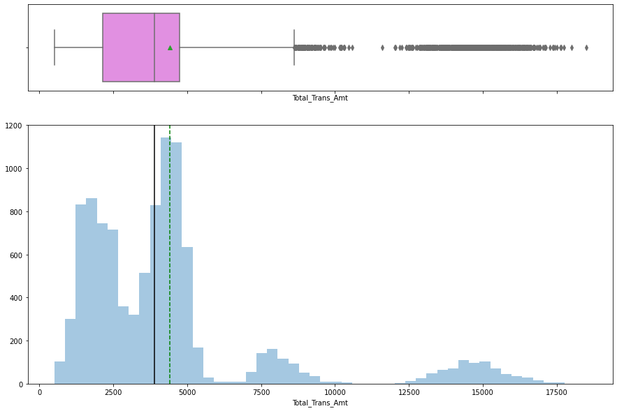

```python
histogram_boxplot(data1['Total_Trans_Amt'])
print(data1['Total_Trans_Amt'].mean())
print(data1['Total_Trans_Amt'].median())
```

```python
#Top highest/smallest values in Total_Trans_Amt
print(data1['Total_Trans_Amt'].nlargest(1))
print(data1['Total_Trans_Amt'].nsmallest(1))
```

```
9964    18484
Name: Total_Trans_Amt, dtype: int64
243    510
Name: Total_Trans_Amt, dtype: int64
```

- Total_Trans_Amt has a right skewed distribution due to the great number of customers having a high transaction amount around 15000.
- Distribution is not symmetric but mean and median are approx equal with values 4400 and 3900, respectively.
- There are many outliers in this variable but to make a capping around 10000 introduce a great distorsion in the set of values, passing the mean from 4400 to 4000. We leave these data like they are.

**Observations on 'Total_Trans_Ct'**

```
64.85869457884863
67.0
```

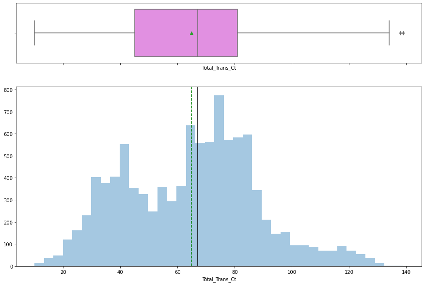

```python
histogram_boxplot(data1['Total_Trans_Ct'])
print(data1['Total_Trans_Ct'].mean())
print(data1['Total_Trans_Ct'].median())
```

- Total_Trans_Ct has a bit left skewed distribution due to the dominance of the smaller number of transactions.
- Distribution is not symmetric but mean and median are approx equal with values 65 and 67, respectively.
- There are a few outliers in this variable. We can make a capping at the value 130.

```python
# Capping values for number of Total_Trans_Ct at 130
data1["Total_Trans_Ct"].clip(upper=130, inplace=True)
```

**Observations on 'Avg_Utilization_Ratio'**

```
0.2748935518909845
0.17600000000000002
```

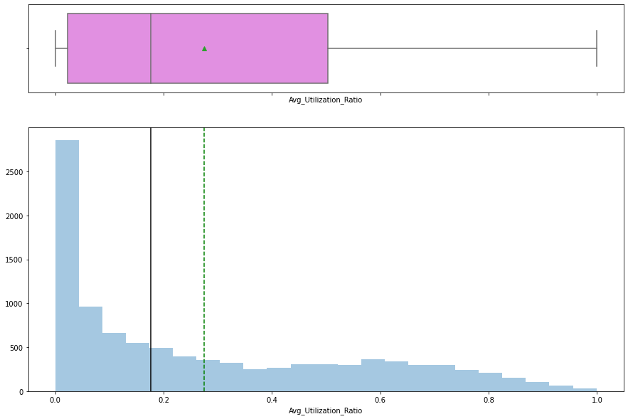

```python
histogram_boxplot(data1['Avg_Utilization_Ratio'])
print(data1['Avg_Utilization_Ratio'].mean())
print(data1['Avg_Utilization_Ratio'].median())
```

- Avg_Utilization_Ratio has a right skewed distribution, but in general the customers have a small utilization ration of the total credit.
- Distribution is not symmetric but mean and median are approx equal with values 0.27 and 0.17, respectively.
- There are not outliers in this variable with range [0,1]. Dont matter to make a capping here.

**Function to create barplots that indicate percentage for each category**

```python
def perc_on_bar(feature):
    '''
    plot
    feature: categorical feature
    the function won't work if a column is passed in hue parameter
    '''
    #Creating a countplot for the feature
    sns.set(rc={'figure.figsize':(15,7)})
    ax=sns.countplot(x=feature, data=data)

    total = len(feature) # length of the column
    for p in ax.patches:
        percentage = '{:.1f}%'.format(100 * p.get_height()/total) # percentage of each class of the category
        x = p.get_x() + p.get_width() / 2 - 0.25 # width of the plot
        y = p.get_y() + p.get_height()           # height of the plot
        ax.annotate(percentage, (x, y), size = 14) # annotate the percantage

    plt.show() # show the plot
```

**Barplots for each category**

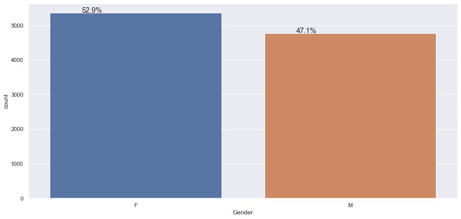

```python
perc_on_bar(data1['Gender'])
```

- Around the 53% of costumers are female.

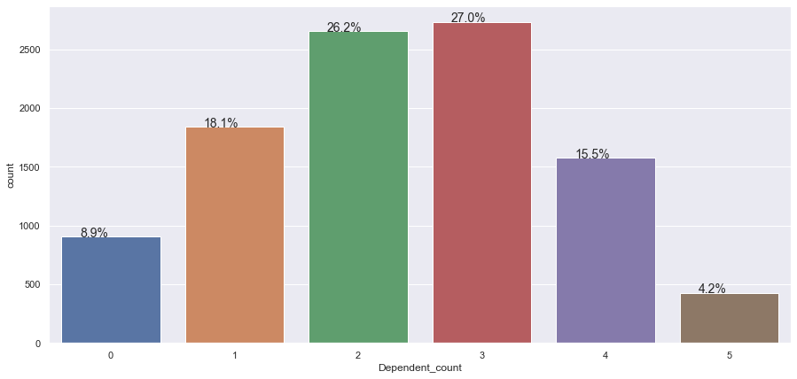

```python
perc_on_bar(data1['Dependent_count'])
```

- Most of the costumers have 2 or 3 people dependent on them.

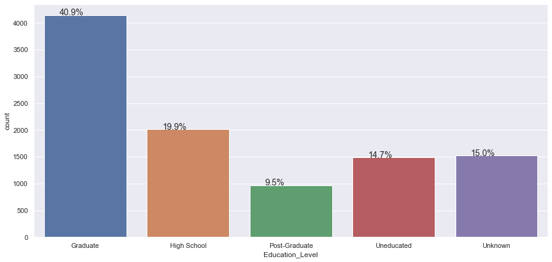

```python
perc_on_bar(data1['Education_Level'])
```

- Most of the costumers, around 70%, have some kind of study.

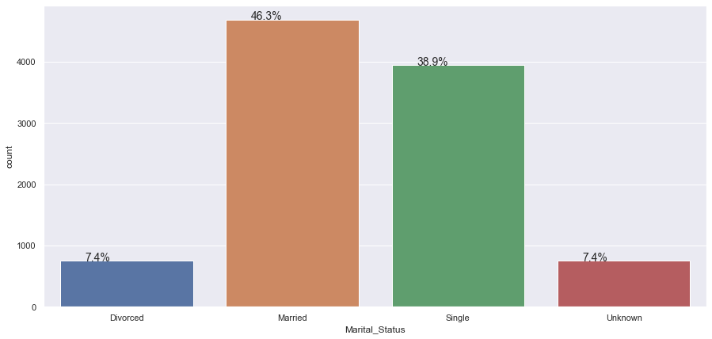

```python
perc_on_bar(data1['Marital_Status'])
```

- Majority of costumers are married (46%) and single (39%)

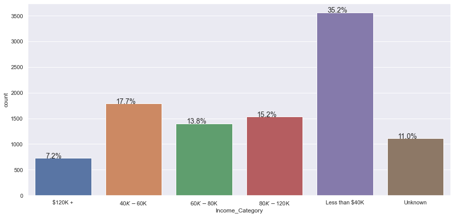

```python
perc_on_bar(data1['Income_Category'])
```

- A percentage greater than 22% has very high incomes, more than 80k.

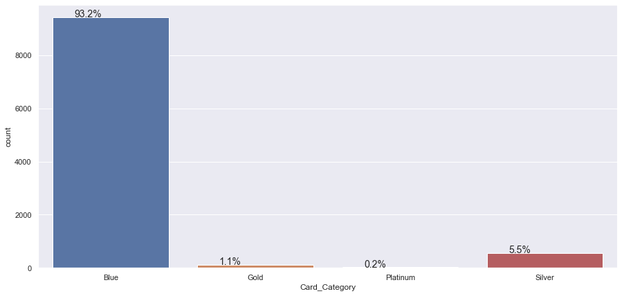

```python
perc_on_bar(data1['Card_Category'])
```

- The majority of customers have the blue card.

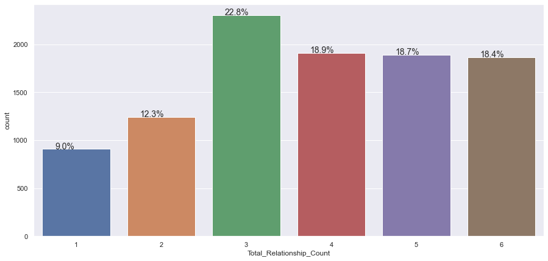

```python
perc_on_bar(data1['Total_Relationship_Count'])
```

- The majority of costumers have hired more than 3 products with the bank.

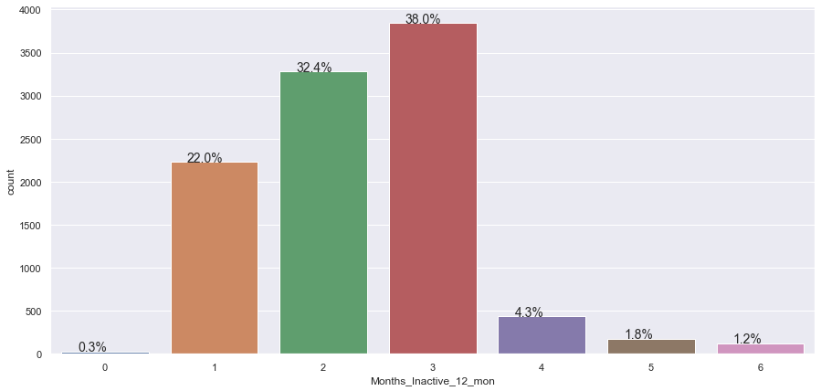

```python
perc_on_bar(data1['Months_Inactive_12_mon'])
```

- The usual situation is to be inactive with the card less than 4 months per year.

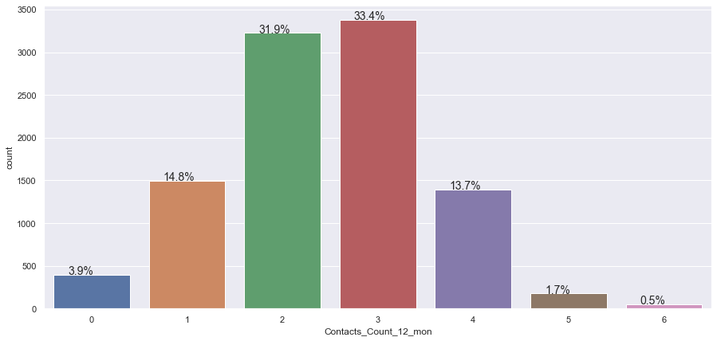

```python
perc_on_bar(data1['Contacts_Count_12_mon'])
```

- The costumers usually dont have more than 3 or 4 contacts per year with the bank.

### Bivariate analysis

```python
# Recalling the dataset
data1.info()
```

```
<class 'pandas.core.frame.DataFrame'>
RangeIndex: 10127 entries, 0 to 10126
Data columns (total 19 columns):
 #   Column                    Non-Null Count  Dtype
---  ------                    --------------  -----
 0   Attrition_Flag            10127 non-null  category
 1   Customer_Age              10127 non-null  int64
 2   Gender                    10127 non-null  category
 3   Dependent_count           10127 non-null  int64
 4   Education_Level           10127 non-null  category
 5   Marital_Status            10127 non-null  category
 6   Income_Category           10127 non-null  category
 7   Card_Category             10127 non-null  category
 8   Months_on_book            10127 non-null  int64
 9   Total_Relationship_Count  10127 non-null  int64
 10  Months_Inactive_12_mon    10127 non-null  int64
 11  Contacts_Count_12_mon     10127 non-null  int64
 12  Credit_Limit              10127 non-null  float64
 13  Total_Revolving_Bal       10127 non-null  int64
 14  Total_Amt_Chng_Q4_Q1      10127 non-null  float64
 15  Total_Trans_Amt           10127 non-null  int64
 16  Total_Trans_Ct            10127 non-null  int64
 17  Total_Ct_Chng_Q4_Q1       10127 non-null  float64
 18  Avg_Utilization_Ratio     10127 non-null  float64
dtypes: category(6), float64(4), int64(9)
memory usage: 1.1 MB
```

```python
# We map the Attrition_Flag to its numerical values to simplify Crosstab
attrition = {'Attrited Customer':1, 'Existing Customer':0}
data1['Attrition_Flag']=data1['Attrition_Flag'].map(attrition)
```

```python
# we start checking through the crosstab function the possible dependencies of Attrition_Flag
columnas = data1.columns[1:19]
print(columnas)
for i in columnas:
    print(pd.crosstab(data1[i],data1['Attrition_Flag'],normalize='columns'))
```

```
Index(['Customer_Age', 'Gender', 'Dependent_count', 'Education_Level',
       'Marital_Status', 'Income_Category', 'Card_Category', 'Months_on_book',
       'Total_Relationship_Count', 'Months_Inactive_12_mon',
       'Contacts_Count_12_mon', 'Credit_Limit', 'Total_Revolving_Bal',
       'Total_Amt_Chng_Q4_Q1', 'Total_Trans_Amt', 'Total_Trans_Ct',
       'Total_Ct_Chng_Q4_Q1', 'Avg_Utilization_Ratio'],
      dtype='object')
Attrition_Flag         1         0
Customer_Age
26              0.003688  0.008471
27              0.001844  0.003412
28              0.000615  0.003294
29              0.004302  0.005765
30              0.009219  0.006471
31              0.007990  0.009176
32              0.010449  0.010471
33              0.012293  0.012588
34              0.011678  0.014941
35              0.012907  0.019176
36              0.014751  0.023176
37              0.022741  0.026235
38              0.028888  0.030118
39              0.029502  0.033529
40              0.039336  0.034941
41              0.046712  0.035647
42              0.038107  0.042824
43              0.052243  0.045647
44              0.051629  0.048941
45              0.048556  0.047882
46              0.050400  0.048000
47              0.046712  0.047412
48              0.052243  0.045529
49              0.048556  0.048941
50              0.043639  0.044824
51              0.035648  0.040000
52              0.035648  0.037412
53              0.036263  0.038588
54              0.042409  0.028000
55              0.031346  0.026824
56              0.026429  0.025765
```

[output cut: 215 more lines]

```
Attrition_Flag                1         0
Avg_Utilization_Ratio
0.000                  0.548863  0.185529
0.004                  0.000615  0.000000
0.005                  0.000615  0.000000
0.006                  0.001844  0.000000
0.007                  0.000615  0.000000
...                         ...       ...
0.990                  0.000615  0.000000
0.992                  0.000615  0.000000
0.994                  0.000000  0.000118
0.995                  0.000615  0.000000
0.999                  0.000615  0.000000

[964 rows x 2 columns]
```

```python
# Converting the 'categorical' data in 'numeric' data to be able to make a pairplot later
from sklearn.preprocessing import LabelEncoder
le = LabelEncoder()
data2 = data1.copy()  #we make another copy of the data
data2['Gender1']=le.fit_transform(data2.Gender)
data2['Education_Level1']=le.fit_transform(data2.Education_Level)
data2['Marital_Status1']=le.fit_transform(data2.Marital_Status)
data2['Income_Category1']=le.fit_transform(data2.Income_Category)
data2['Card_Category1']=le.fit_transform(data2.Card_Category)
data2['Attrition_Flag1']=le.fit_transform(data2.Attrition_Flag)
# we drop the old colummns with categorical datatypes
data2.drop(['Attrition_Flag','Gender','Education_Level','Marital_Status','Income_Category','Card_Category'], axis=1, inplace=True)
data2.info()
data2.nunique()
# Checking the new labeling in one of the columns
print(data2['Gender1'].value_counts())
print(data1['Gender'].value_counts())
```

```
<class 'pandas.core.frame.DataFrame'>
RangeIndex: 10127 entries, 0 to 10126
Data columns (total 19 columns):
 #   Column                    Non-Null Count  Dtype
---  ------                    --------------  -----
 0   Customer_Age              10127 non-null  int64
 1   Dependent_count           10127 non-null  int64
 2   Months_on_book            10127 non-null  int64
 3   Total_Relationship_Count  10127 non-null  int64
 4   Months_Inactive_12_mon    10127 non-null  int64
 5   Contacts_Count_12_mon     10127 non-null  int64
 6   Credit_Limit              10127 non-null  float64
 7   Total_Revolving_Bal       10127 non-null  int64
 8   Total_Amt_Chng_Q4_Q1      10127 non-null  float64
 9   Total_Trans_Amt           10127 non-null  int64
 10  Total_Trans_Ct            10127 non-null  int64
 11  Total_Ct_Chng_Q4_Q1       10127 non-null  float64
 12  Avg_Utilization_Ratio     10127 non-null  float64
 13  Gender1                   10127 non-null  int32
 14  Education_Level1          10127 non-null  int32
 15  Marital_Status1           10127 non-null  int32
 16  Income_Category1          10127 non-null  int32
 17  Card_Category1            10127 non-null  int32
 18  Attrition_Flag1           10127 non-null  int64
dtypes: float64(4), int32(5), int64(10)
memory usage: 1.3 MB
0    5358
1    4769
Name: Gender1, dtype: int64
F    5358
M    4769
Name: Gender, dtype: int64
```

```
Index(['Customer_Age', 'Dependent_count', 'Months_on_book',
       'Total_Relationship_Count', 'Months_Inactive_12_mon',
       'Contacts_Count_12_mon', 'Credit_Limit', 'Total_Revolving_Bal',
       'Total_Amt_Chng_Q4_Q1', 'Total_Trans_Amt', 'Total_Trans_Ct',
       'Total_Ct_Chng_Q4_Q1', 'Avg_Utilization_Ratio', 'Gender1',
       'Education_Level1', 'Marital_Status1', 'Income_Category1',
       'Card_Category1'],
      dtype='object')
```

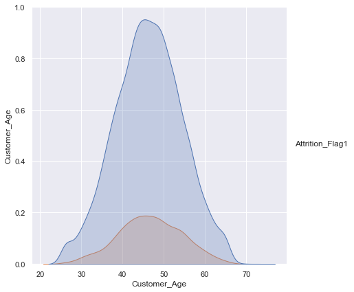

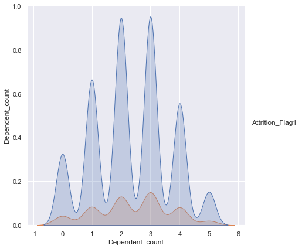

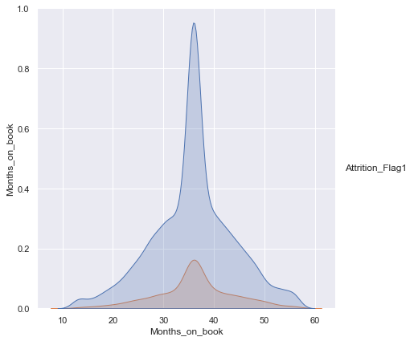

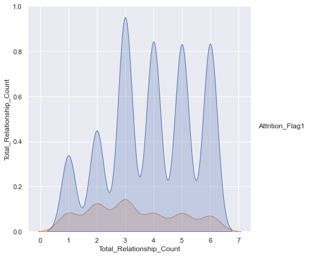

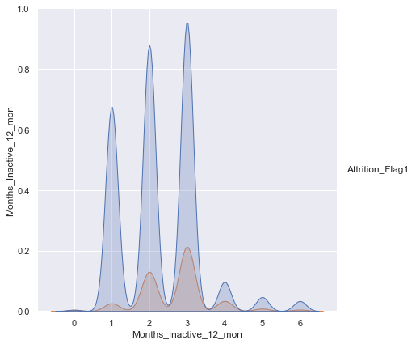

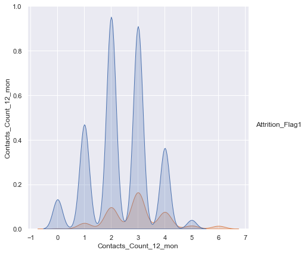

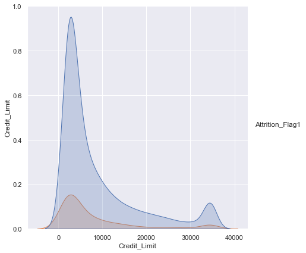

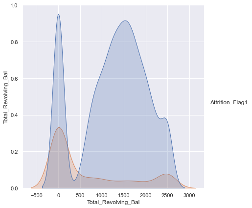

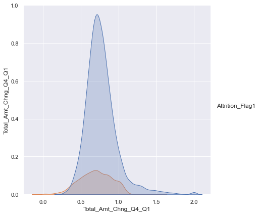

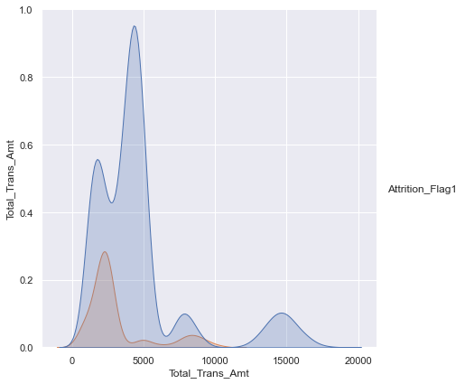

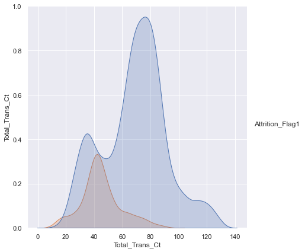

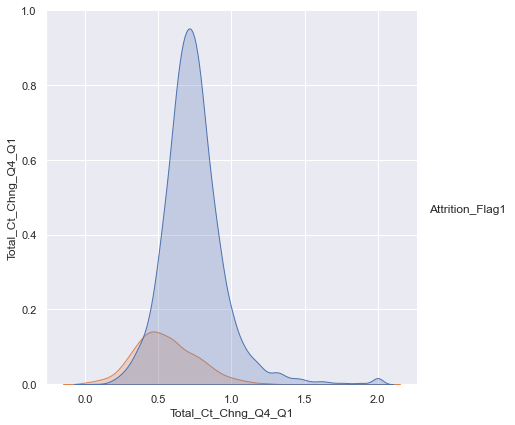

[6 more figures not shown]

```python
# we plot the distribution of each variable grouping by the Attrition_Flag
columnas = data2.columns[0:18]
print(columnas)
for i in columnas:
    plt.figure(figsize=(30,30))
    sns.pairplot(data2, x_vars=[i],y_vars=[i], hue = 'Attrition_Flag1', size=6)
    plt.show()
```

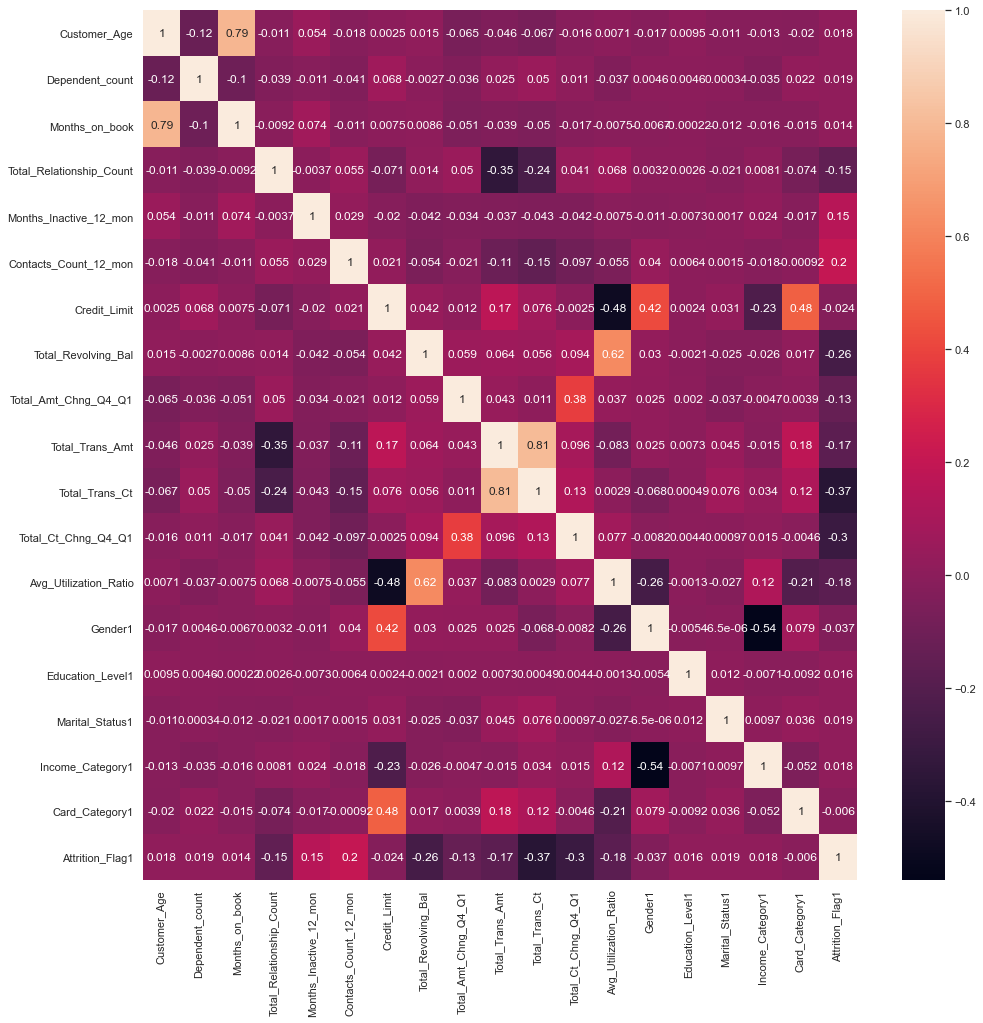

```python
# the correlation in data2 can finally disclose the dependencies of Attrition_Flag respect to all the other variables
corr = data2.corr()
plt.figure(figsize=(16,16))
sns.heatmap(corr, annot = True)
plt.show()
```

## Data Pre-processing

### Data Pre-processing

- Prepare the data for analysis - Missing value Treatment, Outlier Detection(treat, if needed- why or why not ), Feature Engineering, Prepare data for modeling
- Split the Dataset

```python
#Dropping columns and leaving the columns before mentioned in the EDA in a new dataframe data3
data3 = data1[['Attrition_Flag','Total_Trans_Ct','Total_Ct_Chng_Q4_Q1','Total_Revolving_Bal','Contacts_Count_12_mon',
               'Total_Trans_Amt','Months_Inactive_12_mon','Total_Relationship_Count']].copy()
data3.head()
```

|  | Attrition_Flag | Total_Trans_Ct | Total_Ct_Chng_Q4_Q1 | Total_Revolving_Bal | Contacts_Count_12_mon | Total_Trans_Amt | Months_Inactive_12_mon | Total_Relationship_Count |
| --- | --- | --- | --- | --- | --- | --- | --- | --- |
| 0 | 0 | 42 | 1.625 | 777 | 3 | 1144 | 1 | 5 |
| 1 | 0 | 33 | 2.000 | 864 | 2 | 1291 | 1 | 6 |
| 2 | 0 | 20 | 2.000 | 0 | 0 | 1887 | 1 | 4 |
| 3 | 0 | 20 | 2.000 | 2517 | 1 | 1171 | 4 | 3 |
| 4 | 0 | 28 | 2.000 | 0 | 0 | 816 | 1 | 5 |

```python
#Resume of data ready to model
data3.info()
```

```
<class 'pandas.core.frame.DataFrame'>
RangeIndex: 10127 entries, 0 to 10126
Data columns (total 8 columns):
 #   Column                    Non-Null Count  Dtype
---  ------                    --------------  -----
 0   Attrition_Flag            10127 non-null  category
 1   Total_Trans_Ct            10127 non-null  int64
 2   Total_Ct_Chng_Q4_Q1       10127 non-null  float64
 3   Total_Revolving_Bal       10127 non-null  int64
 4   Contacts_Count_12_mon     10127 non-null  int64
 5   Total_Trans_Amt           10127 non-null  int64
 6   Months_Inactive_12_mon    10127 non-null  int64
 7   Total_Relationship_Count  10127 non-null  int64
dtypes: category(1), float64(1), int64(6)
memory usage: 563.9 KB
```

- We dont have non-null values to use the KNN imputer to impute the missing values.
- We dont have categorical variables to generate the dummies.

```python
# We import the libraries we need
# Libraries to tune model, get different metric scores, and split data
from sklearn import metrics
from sklearn.model_selection import train_test_split, StratifiedKFold, cross_val_score
from sklearn.preprocessing import StandardScaler
from sklearn.model_selection import GridSearchCV, RandomizedSearchCV
from sklearn.impute import KNNImputer
from sklearn.pipeline import Pipeline, make_pipeline

#libraries to help with model building
from sklearn.linear_model import LogisticRegression
from sklearn.tree import DecisionTreeClassifier
from sklearn.ensemble import (
    BaggingClassifier,
    AdaBoostClassifier,
    GradientBoostingClassifier,
    RandomForestClassifier)
from xgboost import XGBClassifier
```

```python
# Separating features and the target column Attrition_Flag
X = data3.drop('Attrition_Flag', axis=1)
y = data3['Attrition_Flag']
```

```python
# Splitting the data into train and test sets in 70:30 ratio
X_train, X_test, y_train, y_test = train_test_split(X, y, test_size=0.30, random_state=1, stratify=y)
print(X_train.shape, X_test.shape)
```

```
(7088, 7) (3039, 7)
```

- We have around 7090 observations in the train set and 3040 observations in the test set.

**Before building the models, let's create functions to calculate different metrics- Accuracy, Recall and Precision and plot the confusion matrix.**

```python
## Function to create confusion matrix
def make_confusion_matrix(model,y_actual,labels=[1, 0]):
    '''
    model : classifier to predict values of X
    y_actual : ground truth

    '''
    y_predict = model.predict(X_test)
    cm=metrics.confusion_matrix( y_actual, y_predict, labels=[0, 1])
    df_cm = pd.DataFrame(cm, index = [i for i in ["Actual - No","Actual - Yes"]],
                  columns = [i for i in ['Predicted - No','Predicted - Yes']])
    group_counts = ["{0:0.0f}".format(value) for value in
                cm.flatten()]
    group_percentages = ["{0:.2%}".format(value) for value in
                         cm.flatten()/np.sum(cm)]
    labels = [f"{v1}\n{v2}" for v1, v2 in
              zip(group_counts,group_percentages)]
    labels = np.asarray(labels).reshape(2,2)
    plt.figure(figsize = (10,7))
    sns.heatmap(df_cm, annot=labels,fmt='')
    plt.ylabel('True label')
    plt.xlabel('Predicted label')
```

```python
##  Function to calculate different metric scores of the model - Accuracy, Recall and Precision
def get_metrics_score(model,flag=True):
    '''
    model : classifier to predict values of X

    '''
    # defining an empty list to store train and test results
    score_list=[]

    #Predicting on train and tests
    pred_train = model.predict(X_train)
    pred_test = model.predict(X_test)

    #Accuracy of the model
    train_acc = model.score(X_train,y_train)
    test_acc = model.score(X_test,y_test)

    #Recall of the model
    train_recall = metrics.recall_score(y_train,pred_train)
    test_recall = metrics.recall_score(y_test,pred_test)

    #Precision of the model
    train_precision = metrics.precision_score(y_train,pred_train)
    test_precision = metrics.precision_score(y_test,pred_test)

    score_list.extend((train_acc,test_acc,train_recall,test_recall,train_precision,test_precision))

    # If the flag is set to True then only the following print statements will be dispayed. The default value is set to True.
    if flag == True:
        print("Accuracy on training set : ",model.score(X_train,y_train))
        print("Accuracy on test set : ",model.score(X_test,y_test))
        print("Recall on training set : ",metrics.recall_score(y_train,pred_train))
        print("Recall on test set : ",metrics.recall_score(y_test,pred_test))
        print("Precision on training set : ",metrics.precision_score(y_train,pred_train))
        print("Precision on test set : ",metrics.precision_score(y_test,pred_test))

    return score_list # returning the list with train and test scores
```

**Before going to the detail of each model, we make a first calculation of the Recall for each model by using pipeline, scaling of the data and cross-validation.**

```python
models = []  # Empty list to store all the models

# Appending pipelines for each model into the list
# Logistic Regression, Decision Tree, Random Forest, Bagging, AdaBoost, Gradient Boost and XGBoost models
models.append(
    (
        "LR",
        Pipeline(
            steps=[
                ("scaler", StandardScaler()),
                ("log_reg", LogisticRegression(random_state=1)),
            ]
        ),
    )
)

models.append(
    (
        "DT",
        Pipeline(
            steps=[
                ("scaler", StandardScaler()),
                ("decision_tree", DecisionTreeClassifier(random_state=1)),
            ]
        ),
    )
)

models.append(
    (
        "RF",
        Pipeline(
            steps=[
                ("scaler", StandardScaler()),
                ("random_forest", RandomForestClassifier(random_state=1)),
            ]
        ),
    )
)

models.append(
    (
        "BG",
        Pipeline(
            steps=[
                ("scaler", StandardScaler()),
                ("bagging", BaggingClassifier(random_state=1)),
            ]
        ),
    )
)



models.append(
    (
        "ADB",
        Pipeline(
            steps=[
                ("scaler", StandardScaler()),
                ("adaboost", AdaBoostClassifier(random_state=1)),
            ]
        ),
    )
)

models.append(
    (
        "GBS",
        Pipeline(
            steps=[
                ("scaler", StandardScaler()),
                ("gradient_boosting", GradientBoostingClassifier(random_state=1)),
            ]
        ),
    )
)

models.append(
    (
        "XGB",
        Pipeline(
            steps=[
                ("scaler", StandardScaler()),
                ("xgboost", XGBClassifier(random_state=1,eval_metric='logloss')),
            ]
        ),
    )
)


results = []  # Empty list to store all model's CV scores
names = []  # Empty list to store name of the models

# loop through all models to get the mean cross validated score
for name, model in models:
    scoring = "recall"
    kfold = StratifiedKFold(
        n_splits=5, shuffle=True, random_state=1
    )  # Setting number of splits equal to 5
    cv_result = cross_val_score(
        estimator=model, X=X_train, y=y_train, scoring=scoring, cv=kfold
    )
    results.append(cv_result)
    names.append(name)
    print("{}: {}".format(name, cv_result.mean() * 100))
```

```
LR: 56.62956951850994
DT: 76.47152021021718
RF: 81.21145374449338
BG: 79.54285493469357
ADB: 80.15766287966612
GBS: 80.50892650127521
XGB: 82.35489605069944
```

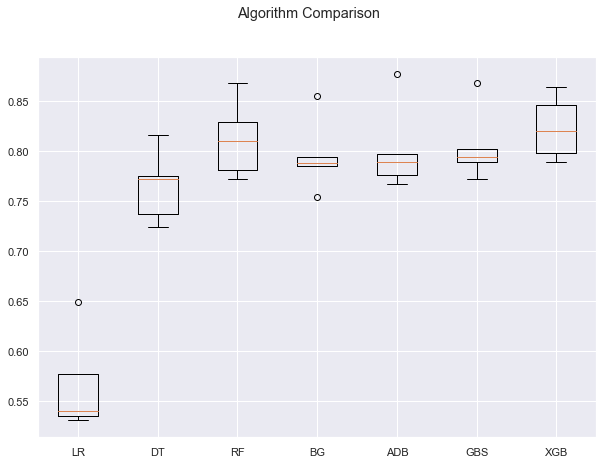

```python
# Plotting boxplots for CV scores of all models defined above
fig = plt.figure(figsize=(10, 7))

fig.suptitle("Algorithm Comparison")
ax = fig.add_subplot(111)

plt.boxplot(results)
ax.set_xticklabels(names)

plt.show()
```

- Clearly, Random Forest and Boosting models with cross-validation give the best results.
- Bagging, AdaBoost and GradientBost models have a lower performance with just an outlier with a higher performance.
- To highlight the very poor result for the LR model with Recall=56% and the good result for the XGB model with Recall=82%.
- At a first sight, it would be enough to try to make the tuning of the RF and the XGB models.
- We also perform the study of the other models to practice the different techniques of tuning.